© Bản quyền thuộc về Quantopian Inc.  
© Bản quyền sửa đổi thuộc về AI Cafe¹  
Giấy phép [Creative Commons Attribution 4.0](https://creativecommons.org/licenses/by/4.0/legalcode).  
[Khuyến cáo](https://aicafe.one/khuyen-cao/)

# ARCH, GARCH và GMM

By Delaney Granizo-Mackenzie and Andrei Kirilenko. Developed as part of the Masters of Finance curriculum at MIT Sloan.

Edited by AI Cafe¹

Mô hình Tự hồi quy điều kiện Heteroskedastic (ARCH) xảy ra khi độ biến động của một chuỗi thời gian cũng là tự hồi quy.

```python
from functools import partial
import math
import numpy as np
import scipy
from scipy import stats
import statsmodels.api as sm
from statsmodels.stats.stattools import jarque_bera

import matplotlib.pyplot as plt
```

## Mô phỏng Trường hợp GARCH(1, 1)

Chúng ta sẽ bắt đầu bằng cách sử dụng lấy mẫu Monte Carlo để mô phỏng một quá trình GARCH(1, 1). Giá trị động của chúng ta sẽ là

$$\sigma_1 = \sqrt{\frac{a_0}{1-a_1-b_1}} \\ \sigma_t^2 = a_0 + a_1 x_{t-1}^2+b_1 \sigma_{t-1}^2 \\ x_t = \sigma_t \epsilon_t \\ \epsilon \sim \mathcal{N}(0, 1)$$

Các tham số của chúng ta sẽ là $a_0 = 1$, $a_1=0.1$, và $b_1=0.8$. Chúng ta sẽ loại bỏ 10% giá trị mô phỏng đầu tiên (thời gian đốt cháy).

```python
# Define parameters
a0 = 1.0
a1 = 0.1
b1 = 0.8
sigma1 = math.sqrt(a0 / (1 - a1 - b1))
```

```python
def simulate_GARCH(T, a0, a1, b1, sigma1):

    # Initialize our values
    X = np.ndarray(T)
    sigma = np.ndarray(T)
    sigma[0] = sigma1

    for t in range(1, T):
        # Draw the next x_t
        X[t - 1] = sigma[t - 1] * np.random.normal(0, 1)
        # Draw the next sigma_t
        sigma[t] = math.sqrt(a0 + b1 * sigma[t - 1]**2 + a1 * X[t - 1]**2)

    X[T - 1] = sigma[T - 1] * np.random.normal(0, 1)

    return X, sigma
```

Bây giờ chúng ta sẽ so sánh phần đuôi của quá trình GARCH(1, 1) với các giá trị phân phối chuẩn. Chúng ta mong đợi thấy các phần đuôi dày hơn, vì quá trình GARCH(1, 1) sẽ trải qua các giá trị cực đoan thường xuyên hơn.

```python
X, _ = simulate_GARCH(10000, a0, a1, b1, sigma1)
X = X[1000:] # Drop burn in
X = X / np.std(X) # Normalize X

def compare_tails_to_normal(X):
    # Define matrix to store comparisons
    A = np.zeros((2,4))
    for k in range(4):
        A[0, k] = len(X[X > (k + 1)]) / float(len(X)) # Estimate tails of X
        A[1, k] = 1 - stats.norm.cdf(k + 1) # Compare to Gaussian distribution
    return A

compare_tails_to_normal(X)
```

```
array([[1.51222222e-01, 2.34444444e-02, 2.11111111e-03, 1.11111111e-04],
       [1.58655254e-01, 2.27501319e-02, 1.34989803e-03, 3.16712418e-05]])
```

Quả thực, các phần đuôi của quá trình GARCH(1, 1) dày hơn. Chúng ta cũng có thể nhìn vào điều này dưới dạng đồ họa, mặc dù có thể hơi khó nhìn.

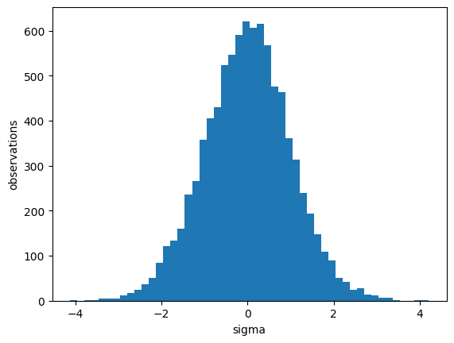

```python
plt.hist(X, bins=50)
plt.xlabel('sigma')
plt.ylabel('observations');
```

```python
# Sample values from a normal distribution
X2 = np.random.normal(0, 1, 9000)
both = np.matrix([X, X2])
```

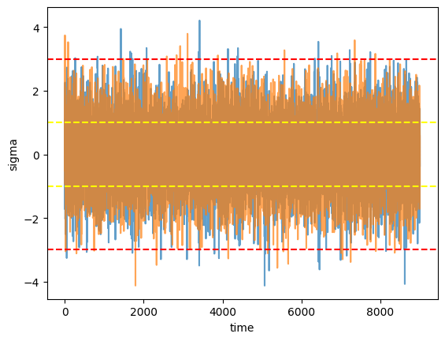

```python
# Plot both the GARCH and normal values
plt.plot(both.T, alpha=.7);
plt.axhline(X2.std(), color='yellow', linestyle='--')
plt.axhline(-X2.std(), color='yellow', linestyle='--')
plt.axhline(3*X2.std(), color='red', linestyle='--')
plt.axhline(-3*X2.std(), color='red', linestyle='--')
plt.xlabel('time')
plt.ylabel('sigma');
```

Điều chúng ta đang xem ở đây là quá trình GARCH được hiển thị bằng màu xanh và quá trình chuẩn được hiển thị bằng màu cam. Các thanh chuẩn độ lệch chuẩn 1 và 3 đã được vẽ trên đồ thị. Chúng ta có thể thấy rằng quá trình GARCH màu xanh thường xuyên vượt qua thanh 3 độ lệch chuẩn nhiều hơn so với quá trình chuẩn màu cam.

## Kiểm tra Hành vi ARCH

Bước đầu tiên là kiểm tra các điều kiện ARCH. Để làm điều này, chúng ta thực hiện hồi quy trên $x_t$ theo mô hình sau.

$$x_t^2 = a_0 + a_1 x_{t-1}^2 + \dots + a_p x_{t-p}^2$$

Chúng ta sử dụng OLS để ước lượng $\hat\theta = (\hat a_0, \hat a_1, \dots, \hat a_p)$ và ma trận hiệp phương sai $\hat\Omega$. Sau đó, chúng ta có thể tính toán thống kê kiểm tra

$$F = \hat\theta \hat\Omega^{-1} \hat\theta'$$

Chúng ta sẽ bác bỏ giả thuyết nếu $F$ lớn hơn các thanh độ tin cậy 95% trong phân phối $\mathcal(X)^2(p)$.

Để kiểm tra, chúng ta sẽ đặt $p=20$ và xem chúng ta nhận được gì.

```
(20, 1)
F = 296.336232415511
p-value = 0.0
[[ 54.07236343  22.51441516  42.57497935  45.00739559  40.39733385
   27.92315948  27.0094377   26.74565963  12.66784606  11.06781779
    8.71982699  -5.3161232   12.54578233  27.57148368   5.3074843
   32.62344818  13.39862067 -14.138459    -2.24162147 -19.48697705]]
```

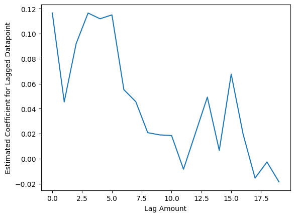

```python
X, _ = simulate_GARCH(1100, a0, a1, b1, sigma1)
X = X[100:] # Drop burn in

p = 20

# Drop the first 20 so we have a lag of p's
Y2 = (X**2)[p:]
X2 = np.ndarray((980, p))
for i in range(p, 1000):
    X2[i - p, :] = np.asarray((X**2)[i-p:i])[::-1]

model = sm.OLS(Y2, X2)
model = model.fit()
theta = np.matrix(model.params)
omega = np.matrix(model.cov_HC0)
F = (theta * np.linalg.inv(omega) * theta.T).item()

print(np.asarray(theta.T).shape)

plt.plot(range(20), np.asarray(theta.T))
plt.xlabel('Lag Amount')
plt.ylabel('Estimated Coefficient for Lagged Datapoint')

print('F = ' + str(F))

chi2dist = scipy.stats.chi2(p)
pvalue = 1-chi2dist.cdf(F)
print('p-value = ' + str(pvalue))

# Finally let's look at the significance of each a_p as measured by the standard deviations away from 0
print(theta/np.diag(omega))
```

## Fitting GARCH(1, 1) với MLE

Một khi chúng ta đã quyết định rằng dữ liệu có thể có một mô hình GARCH(1, 1) tiềm ẩn, chúng ta sẽ tiến hành điều chỉnh GARCH(1, 1) cho dữ liệu bằng cách ước lượng các tham số.

Để làm điều này, chúng ta cần hàm log-likelihood

$$\mathcal{L}(\theta) = \sum_{t=1}^T - \ln \sqrt{2\pi} - \frac{x_t^2}{2\sigma_t^2} - \frac{1}{2}\ln(\sigma_t^2)$$

Để đánh giá hàm này, chúng ta cần $x_t$ và $\sigma_t$ cho $1 \leq t \leq T$. Chúng ta đã có $x_t$, nhưng chúng ta cần tính toán $\sigma_t$. Để làm điều này, chúng ta cần đưa ra một ước lượng cho $\sigma_1$. Dự đoán của chúng ta sẽ là $\sigma_1^2 = \hat E[x_t^2]$. Khi có ước lượng ban đầu, chúng ta tính toán các giá trị còn lại của $\sigma$ bằng công thức

$$\sigma_t^2 = a_0 + a_1 x_{t-1}^2 + b_1\sigma_{t-1}^2$$

```python
X, _ = simulate_GARCH(10000, a0, a1, b1, sigma1)
X = X[1000:] # Drop burn in
```

```python
# Here's our function to compute the sigmas given the initial guess
def compute_squared_sigmas(X, initial_sigma, theta):

    a0 = theta[0]
    a1 = theta[1]
    b1 = theta[2]

    T = len(X)
    sigma2 = np.ndarray(T)

    sigma2[0] = initial_sigma ** 2

    for t in range(1, T):
        # Here's where we apply the equation
        sigma2[t] = a0 + a1 * X[t-1]**2 + b1 * sigma2[t-1]

    return sigma2
```

Hãy xem xét các giá trị sigma mà chúng ta vừa tạo ra.

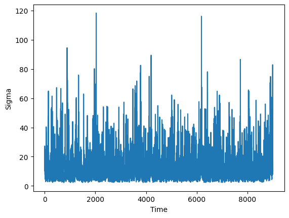

```python
plt.plot(range(len(X)), compute_squared_sigmas(X, np.sqrt(np.mean(X**2)), (1, 0.5, 0.5)))
plt.xlabel('Time')
plt.ylabel('Sigma');
```

Bây giờ chúng ta có thể tính toán các $\sigma_t$, chúng ta sẽ định nghĩa hàm log likelihood thực tế. Hàm này sẽ nhận vào các quan sát của chúng ta $x$ và $\theta$ và trả về $-\mathcal{L}(\theta)$. Điều quan trọng cần lưu ý là chúng ta trả về log likelihood âm, vì như vậy, bộ tối ưu hóa số của chúng ta có thể tối thiểu hóa hàm trong khi tối đa hóa log likelihood.

Lưu ý rằng chúng ta đang liên tục tính toán lại các $\sigma_t$ trong hàm này.

```python
def negative_log_likelihood(X, theta):

    T = len(X)

    # Estimate initial sigma squared
    initial_sigma = np.sqrt(np.mean(X ** 2))

    # Generate the squared sigma values
    sigma2 = compute_squared_sigmas(X, initial_sigma, theta)

    # Now actually compute
    return -sum(
        [-np.log(np.sqrt(2.0 * np.pi)) -
        (X[t] ** 2) / (2.0 * sigma2[t]) -
        0.5 * np.log(sigma2[t]) for
         t in range(T)]
    )
```

Bây giờ chúng ta thực hiện tối ưu hóa số để tìm ước lượng của chúng ta cho $$\hat\theta = \arg \max_{(a_0, a_1, b_1)}\mathcal{L}(\theta) = \arg \min_{(a_0, a_1, b_1)}-\mathcal{L}(\theta)$$

Chúng ta có một số ràng buộc về điều này

$$a_1 \geq 0, b_1 \geq 0, a_1+b_1 < 1$$

```python
# Make our objective function by plugging X into our log likelihood function
objective = partial(negative_log_likelihood, X)

# Define the constraints for our minimizer
def constraint1(theta):
    return np.array([1 - (theta[1] + theta[2])])

def constraint2(theta):
    return np.array([theta[1]])

def constraint3(theta):
    return np.array([theta[2]])

cons = ({'type': 'ineq', 'fun': constraint1},
        {'type': 'ineq', 'fun': constraint2},
        {'type': 'ineq', 'fun': constraint3})

# Actually do the minimization
result = scipy.optimize.minimize(objective, (1, 0.5, 0.5),
                        method='SLSQP',
                        constraints = cons)
theta_mle = result.x
print('theta MLE: ' + str(theta_mle))
```

```
theta MLE: [0.88590229 0.09500559 0.82077142]
```

Bây giờ chúng ta muốn có một cách để kiểm tra ước lượng của mình. Chúng ta sẽ xem xét hai điều:

1. Đuôi của các phần dư dày như thế nào.
2. Các phần dư có chuẩn hay không theo bài kiểm tra tính chuẩn Jarque-Bera.

Chúng ta sẽ thực hiện cả hai điều này trong hàm `check_theta_estimate` của chúng ta.

```python
def check_theta_estimate(X, theta_estimate):
    initial_sigma = np.sqrt(np.mean(X ** 2))
    sigma = np.sqrt(compute_squared_sigmas(X, initial_sigma, theta_estimate))
    epsilon = X / sigma
    print('Tails table')
    print(compare_tails_to_normal(epsilon / np.std(epsilon)))

    _, pvalue, _, _ = jarque_bera(epsilon)
    print('Jarque-Bera probability normal: ' + str(pvalue))

check_theta_estimate(X, theta_mle)
```

```
Tails table
[[1.57111111e-01 2.42222222e-02 1.66666667e-03 0.00000000e+00]
 [1.58655254e-01 2.27501319e-02 1.34989803e-03 3.16712418e-05]]
Jarque-Bera probability normal: 0.09508221201960755
```

## GMM để Ước Lượng Tham Số GARCH(1, 1)

Chúng ta vừa tính toán một ước lượng bằng phương pháp MLE, nhưng chúng ta cũng có thể sử dụng Phương Pháp Tổng Quát Thời Điểm (GMM) để ước lượng các tham số GARCH(1, 1).

Để làm điều này, chúng ta cần định nghĩa các thời điểm của mình. Chúng ta sẽ sử dụng 4 thời điểm.

1. Phần dư $\hat\epsilon_t = x_t / \hat\sigma_t$
2. Phương sai của phần dư $\hat\epsilon_t^2$
3. Thời điểm lệch $\mu_3/\hat\sigma_t^3 = (\hat\epsilon_t - E[\hat\epsilon_t])^3 / \hat\sigma_t^3$
4. Thời điểm độ nhọn $\mu_4/\hat\sigma_t^4 = (\hat\epsilon_t - E[\hat\epsilon_t])^4 / \hat\sigma_t^4$

```python
# The n-th standardized moment
# skewness is 3, kurtosis is 4
def standardized_moment(x, mu, sigma, n):
    return ((x - mu) ** n) / (sigma ** n)
```

GMM hiện có ba bước.

Bắt đầu với $W$ là ma trận đơn vị.

1. Ước lượng $\hat\theta_1$ bằng cách sử dụng tối ưu hóa số để tối thiểu hóa

$$\min_{\theta \in \Theta} \left(\frac{1}{T} \sum_{t=1}^T g(x_t, \hat\theta)\right)' W \left(\frac{1}{T}\sum_{t=1}^T g(x_t, \hat\theta)\right)$$

2. Tính lại $W$ dựa trên phương sai của các ước lượng $\theta$. (Tập trung nhiều hơn vào các tham số có sức giải thích)

$$\hat W_{i+1} = \left(\frac{1}{T}\sum_{t=1}^T g(x_t, \hat\theta_i)g(x_t, \hat\theta_i)'\right)^{-1}$$

3. Lặp lại cho đến khi $|\hat\theta_{i+1} - \hat\theta_i| < \epsilon$ hoặc chúng ta đạt đến ngưỡng lặp.

Khởi tạo $W$ và $T$ và định nghĩa hàm mục tiêu mà chúng ta cần tối thiểu hóa.

```python
def gmm_objective(X, W, theta):
    # Compute the residuals for X and theta
    initial_sigma = np.sqrt(np.mean(X ** 2))
    sigma = np.sqrt(compute_squared_sigmas(X, initial_sigma, theta))
    e = X / sigma

    # Compute the mean moments
    m1 = np.mean(e)
    m2 = np.mean(e ** 2) - 1
    m3 = np.mean(standardized_moment(e, np.mean(e), np.std(e), 3))
    m4 = np.mean(standardized_moment(e, np.mean(e), np.std(e), 4) - 3)

    G = np.matrix([m1, m2, m3, m4]).T

    return (G.T * W * G).item()

def gmm_variance(X, theta):
    # Compute the residuals for X and theta
    initial_sigma = np.sqrt(np.mean(X ** 2))
    sigma = np.sqrt(compute_squared_sigmas(X, initial_sigma, theta))
    e = X / sigma

    # Compute the squared moments
    m1 = e ** 2
    m2 = (e ** 2 - 1) ** 2
    m3 = standardized_moment(e, np.mean(e), np.std(e), 3) ** 2
    m4 = (standardized_moment(e, np.mean(e), np.std(e), 4) - 3) ** 2

    # Compute the covariance matrix g * g'
    T = len(X)
    s = np.ndarray((4, 1))
    for t in range(T):
        G = np.matrix([m1[t], m2[t], m3[t], m4[t]]).T
        s = s + G * G.T

    return s / T
```

Bây giờ chúng ta đã sẵn sàng để thực hiện bước tối thiểu hóa lặp lại.

```python
# Initialize GMM parameters
W = np.identity(4)
gmm_iterations = 10

# First guess
theta_gmm_estimate = theta_mle

# Perform iterated GMM
for i in range(gmm_iterations):
    # Estimate new theta
    objective = partial(gmm_objective, X, W)
    result = scipy.optimize.minimize(objective, theta_gmm_estimate, constraints=cons)
    theta_gmm_estimate = result.x
    print('Iteration ' + str(i) + ' theta: ' + str(theta_gmm_estimate))

    # Recompute W
    W = np.linalg.inv(gmm_variance(X, theta_gmm_estimate))

check_theta_estimate(X, theta_gmm_estimate)
```

```
Iteration 0 theta: [0.89019423 0.0825734  0.83160588]
Iteration 1 theta: [0.89016734 0.08232793 0.83133819]
Iteration 2 theta: [0.89016734 0.08232793 0.83133819]
Iteration 3 theta: [0.89016734 0.08232793 0.83133819]
Iteration 4 theta: [0.89016734 0.08232793 0.83133819]
Iteration 5 theta: [0.89016734 0.08232793 0.83133819]
Iteration 6 theta: [0.89016734 0.08232793 0.83133819]
Iteration 7 theta: [0.89016734 0.08232793 0.83133819]
Iteration 8 theta: [0.89016734 0.08232793 0.83133819]
Iteration 9 theta: [0.89016734 0.08232793 0.83133819]
Tails table
[[1.57777778e-01 2.40000000e-02 1.55555556e-03 0.00000000e+00]
 [1.58655254e-01 2.27501319e-02 1.34989803e-03 3.16712418e-05]]
Jarque-Bera probability normal: 0.1056972629873449
```

## Dự đoán Tương lai: Cách thực sự sử dụng những gì chúng ta đã làm

Bây giờ chúng ta đã điều chỉnh một mô hình cho các quan sát của mình, chúng ta muốn có khả năng dự đoán sự biến động trong tương lai sẽ như thế nào. Để làm điều này, chúng ta có thể chỉ cần mô phỏng thêm các giá trị bằng cách sử dụng động lực GARCH ban đầu của chúng ta và các tham số ước lượng.

Điều đầu tiên chúng ta sẽ làm là tính toán một $\sigma_t$ ban đầu. Chúng ta sẽ tính toán các sigma bình phương và lấy giá trị cuối cùng.

```python
sigma_hats = np.sqrt(compute_squared_sigmas(X, np.sqrt(np.mean(X**2)), theta_mle))
initial_sigma = sigma_hats[-1]
initial_sigma
```

```
np.float64(3.7993793531560414)
```

Bây giờ chúng ta sẽ chỉ lấy mẫu giá trị khi tiến về phía trước.

```python
a0_estimate = theta_gmm_estimate[0]
a1_estimate = theta_gmm_estimate[1]
b1_estimate = theta_gmm_estimate[2]

X_forecast, sigma_forecast = simulate_GARCH(100, a0_estimate, a1_estimate, b1_estimate, initial_sigma)
```

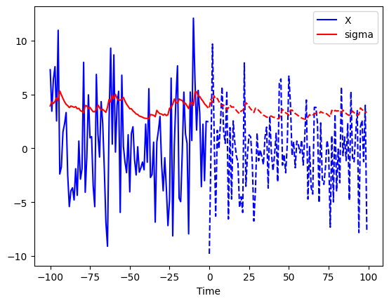

```python
plt.plot(range(-100, 0), X[-100:], 'b-')
plt.plot(range(-100, 0), sigma_hats[-100:], 'r-')
plt.plot(range(0, 100), X_forecast, 'b--')
plt.plot(range(0, 100), sigma_forecast, 'r--')
plt.xlabel('Time')
plt.legend(['X', 'sigma']);
```

Một điểm cần lưu ý là vì chúng ta đang tiến lên bằng cách sử dụng một bước ngẫu nhiên, nên phân tích này nhằm mục đích cho chúng ta cảm nhận về độ lớn của sigma và do đó là rủi ro mà chúng ta có thể phải đối mặt. Nó không nhằm mục đích mô hình hóa chính xác các giá trị tương lai của X. Trong thực tế, bạn có thể muốn sử dụng mẫu Monte Carlo để tạo ra hàng nghìn kịch bản tương lai, và sau đó xem xét phạm vi tiềm năng của các đầu ra. Chúng ta sẽ thử điều đó bây giờ. Hãy nhớ rằng đây là một cách khá đơn giản để thực hiện phân tích này, và có những kỹ thuật tốt hơn, chẳng hạn như các hình nón Bayesian, tồn tại.

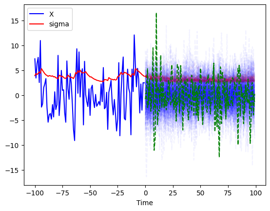

```python
from IPython.display import clear_output

plt.plot(range(-100, 0), X[-100:], 'b-')
plt.plot(range(-100, 0), sigma_hats[-100:], 'r-')
plt.xlabel('Time')
plt.legend(['X', 'sigma'])

max_X = [-np.inf]
min_X = [np.inf]
for i in range(100):

    print(f'iteration {i+1} of 100')
    clear_output(wait=True)

    X_forecast, sigma_forecast = simulate_GARCH(100, a0_estimate, a1_estimate, b1_estimate, initial_sigma)
    if max(X_forecast) > max(max_X):
        max_X = X_forecast
    elif min(X_forecast) < min(max_X):
        min_X = X_forecast
    plt.plot(range(0, 100), X_forecast, 'b--', alpha=0.05)
    plt.plot(range(0, 100), sigma_forecast, 'r--', alpha=0.05)

# Draw the most extreme X values specially
plt.plot(range(0, 100), max_X, 'g--', alpha=1.0)
plt.plot(range(0, 100), min_X, 'g--', alpha=1.0);
```

*Lưu ý: Tài liệu này mang tính chất chia sẻ kiến thức khoa học dữ liệu. Các mã chứng khoán xuất hiện trong tài liệu chỉ mang tính chất minh hoạ, không khuyến nghị đầu tư. Chúng tôi không chịu trách nhiệm trước mọi rủi ro nào do sử dụng tài liệu này.*